# 链家二手房数据分析报告

周斌2023281051033

2023-10-18

# 1 数据介绍

本报告**链家**数据获取方式如下：

报告人在2023年9月12日获取了[链家武汉二手房网站](https://wh.lianjia.com/ershoufang/)数据。

- 链家二手房网站默认显示100页，每页30套房产，因此本数据包括3000套房产信息；
- 数据包括了页面可见部分的文本信息，具体字段及说明见作业说明。

**说明：**数据仅用于教学；由于不清楚链家数据的展示规则，因此数据可能并不是武汉二手房市场的随机抽样，结论很可能有很大的偏差，甚至可能是错误的。

各变量的简短信息：

```
## Rows: 3,000
## Columns: 18
## $ property_name     <chr> "南湖名都A区", "万科紫悦湾", "东立国际", "新都汇", "…
## $ property_region   <chr> "南湖沃尔玛", "光谷东", "二七", "光谷广场", "团结大…
## $ price_ttl         <dbl> 237.0, 127.0, 75.0, 188.0, 182.0, 122.0, 99.0, 193.8…
## $ price_sqm         <dbl> 18709, 14613, 15968, 15702, 17509, 10376, 12346, 163…
## $ bedrooms          <dbl> 3, 3, 1, 3, 3, 3, 2, 3, 4, 3, 5, 3, 4, 3, 3, 2, 3, 4…
## $ livingrooms       <dbl> 1, 2, 1, 2, 2, 2, 1, 2, 1, 2, 2, 2, 2, 1, 2, 2, 2, 2…
## $ building_area     <dbl> 126.68, 86.91, 46.97, 119.73, 103.95, 117.59, 80.19,…
## $ directions1       <chr> "南", "南", "南", "北", "东南", "南", "南", "南", "…
## $ directions2       <chr> "北", NA, NA, "东", NA, "北", NA, "北", "北", "北", …
## $ decoration        <chr> "精装", "精装", "简装", "精装", "简装", "精装", "简…
## $ property_t_height <dbl> 17, 28, 18, 32, 34, 34, 7, 34, 5, 7, 25, 32, 8, 31, …
## $ property_height   <chr> "中", "中", "低", "高", "中", "低", "低", "中", "低"…
## $ property_style    <chr> "塔楼", "板楼", "塔楼", "塔楼", "板塔结合", "板楼", …
## $ followers         <dbl> 3, 1, 3, 2, 3, 1, 0, 0, 2, 0, 0, 0, 10, 0, 0, 1, 0, …
## $ near_subway       <chr> "近地铁", NA, "近地铁", "近地铁", NA, NA, "近地铁", …
## $ if_2y             <chr> NA, "房本满两年", NA, "房本满两年", "房本满两年", "…
## $ has_key           <chr> "随时看房", "随时看房", "随时看房", "随时看房", "随…
## $ vr                <chr> NA, "VR看装修", NA, NA, "VR看装修", NA, "VR看装修", …
```

各变量的简短统计：

```
##  property_name      property_region      price_ttl        price_sqm
##  Length:3000        Length:3000        Min.   :  10.6   Min.   : 1771
##  Class :character   Class :character   1st Qu.:  95.0   1st Qu.:10799
##  Mode  :character   Mode  :character   Median : 137.0   Median :14404
##                                        Mean   : 155.9   Mean   :15148
##                                        3rd Qu.: 188.0   3rd Qu.:18211
##                                        Max.   :1380.0   Max.   :44656
##     bedrooms      livingrooms    building_area    directions1
##  Min.   :1.000   Min.   :0.000   Min.   : 22.77   Length:3000
##  1st Qu.:2.000   1st Qu.:1.000   1st Qu.: 84.92   Class :character
##  Median :3.000   Median :2.000   Median : 95.55   Mode  :character
##  Mean   :2.695   Mean   :1.709   Mean   :100.87
##  3rd Qu.:3.000   3rd Qu.:2.000   3rd Qu.:117.68
##  Max.   :7.000   Max.   :4.000   Max.   :588.66
##  directions2         decoration        property_t_height property_height
##  Length:3000        Length:3000        Min.   : 2.00     Length:3000
##  Class :character   Class :character   1st Qu.:11.00     Class :character
##  Mode  :character   Mode  :character   Median :27.00     Mode  :character
##                                        Mean   :24.22
##                                        3rd Qu.:33.00
##                                        Max.   :62.00
##  property_style       followers       near_subway           if_2y
##  Length:3000        Min.   :  0.000   Length:3000        Length:3000
##  Class :character   1st Qu.:  1.000   Class :character   Class :character
##  Mode  :character   Median :  3.000   Mode  :character   Mode  :character
##                     Mean   :  6.614
##                     3rd Qu.:  6.000
##                     Max.   :262.000
##    has_key               vr
##  Length:3000        Length:3000
##  Class :character   Class :character
##  Mode  :character   Mode  :character
##
##
##
```

可以看到：

1.总价（price_ttl）的最小值为10.6w，最大值为1380.0w，平均值为155.9w。

2.单价（price_sqm）的最小值为1771，最大值为44656，平均值为15148。

3.卧室数量（bedrooms）的最小值为1，最大值为7，平均值为2.695。

4.客厅数量（livingrooms）的最小值为0，最大值为4，平均值为1.709。

5.建筑面积（building_area）的最小值为22.77，最大值为588.66，平均值为100.87

6.主要朝向（directions1）最多为南

7.次要朝向（directions2）最多为北

8.装修状况（decoration）最多为精装

9.楼栋总层数（property_t_height）最多为33，其次为34，最高为62

10.建筑形式（property_style）最多板楼

11.二手房网站的关注人数（followers）最多为262

# 2 探索性分析

## 2.1 数值描述与图形1:箱线图

#### 2.1.0.1 绘制一个基于price_sqm和property_region的箱线图，以比较不同地区的价格分布情况。每个地区的箱线图会以不同的颜色进行区分

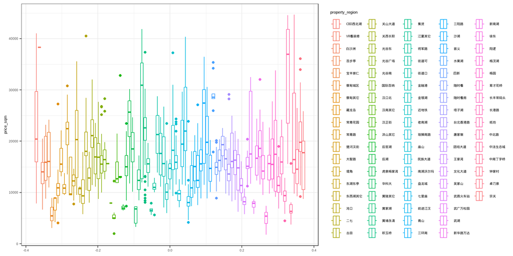

发现：

- 中北路的价格中间值和最大值，都是在整个武汉区域最高的

## 2.2 数值描述与图形2:直方图

#### 2.2.0.1 按照property_region,进行分组，统计出数量大于60的楼盘数量的直方图

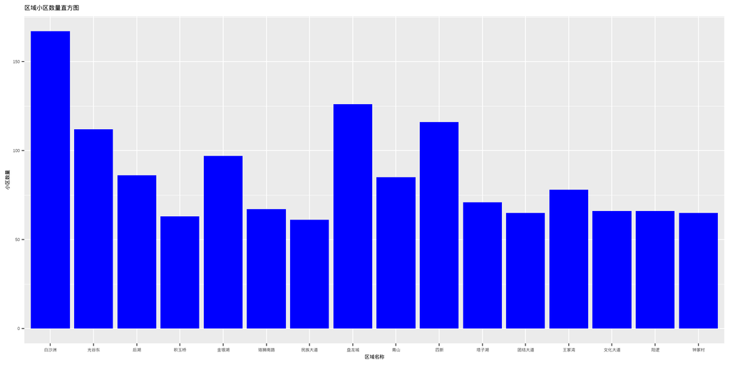

发现： - 白沙洲片区楼盘最多，其次为盘龙城

## 2.3 数值描述与图形3:比例直方图

[figure not shown]

## 2.4 探索问题1:房屋的建筑面积和房屋单价是否存在递增关系？

#### 2.4.0.1 提取楼盘数最多的片区(白沙洲)，标绘出横轴为建筑面积和房屋单价的折线图

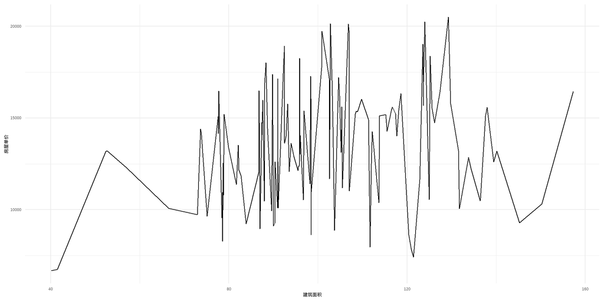

发现：

- 房屋单价在房屋建筑面积为80-140这个区间，并不是随房屋建筑面积的增加，房屋单价会递增，而是基本保持一个均线趋势
- 房屋单价的高低，和建筑面接没有太大的关系

## 2.5 探索问题2:房屋单价和是否靠近地铁是否有关系?

#### 2.5.0.1 分别绘制是否靠近地铁房价的箱线图

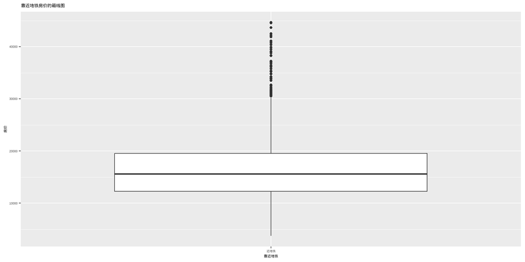

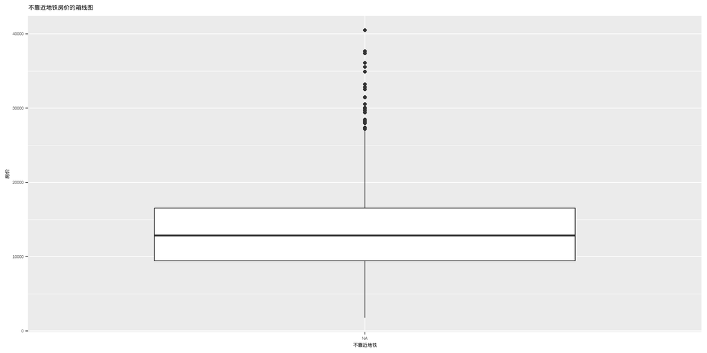

发现：

- 靠近地铁的房价比不靠近地图的房屋单价上限，中位数都要高
- 房屋单价和是否靠近地铁有关系

# 3 发现总结

– 房屋价格和多个因素有关，例如是否靠近地铁，房屋所在的区域，这些因素有关的房屋升值空间大

– 房屋单价和房屋的面积并没有直接的关系，为了分散投资降低风险，可以采取购买多套小户型的房屋